# The Importance of Handwashing

Dr. Ignaz Semmelweis is a Hungarian physician born in 1818 and active at the Vienna General Hospital. If Dr. Semmelweis looks troubled it’s probably because he’s thinking about childbed fever: A deadly disease affecting women that just have given birth. He is thinking about it because in the early 1840s at the Vienna General Hospital as many as 10% of the women giving birth die from it. He is thinking about it because he knows the cause of childbed fever: It’s the contaminated hands of the doctors delivering the babies. And they won’t listen to him and wash their hands!

In this notebook, we’re going to reanalyze the data that made Semmelweis discover the importance of handwashing. Let’s start by looking at the data that made Semmelweis realize that something was wrong with the procedures at Vienna General Hospital.

## Yearly Data

| year | births | deaths | clinic |
| --- | --- | --- | --- |
| 1841 | 3036 | 237 | clinic 1 |
| 1842 | 3287 | 518 | clinic 1 |
| 1843 | 3060 | 274 | clinic 1 |
| 1844 | 3157 | 260 | clinic 1 |
| 1845 | 3492 | 241 | clinic 1 |
| 1846 | 4010 | 459 | clinic 1 |
| 1841 | 2442 | 86 | clinic 2 |
| 1842 | 2659 | 202 | clinic 2 |
| 1843 | 2739 | 164 | clinic 2 |
| 1844 | 2956 | 68 | clinic 2 |
| 1845 | 3241 | 66 | clinic 2 |
| 1846 | 3754 | 105 | clinic 2 |

## The alarming number of deaths

The table above shows the number of women giving birth at the two clinics at the Vienna General Hospital for the years 1841 to 1846. You’ll notice that giving birth was very dangerous; an *alarming* number of women died as the result of childbirth, most of them from childbed fever.

We see this more clearly if we look at the *proportion of deaths* out of the number of women giving birth.

| year | births | deaths | clinic | proportion_deaths |
| --- | --- | --- | --- | --- |
| 1841 | 3036 | 237 | clinic 1 | 0.0780632 |
| 1842 | 3287 | 518 | clinic 1 | 0.1575905 |
| 1843 | 3060 | 274 | clinic 1 | 0.0895425 |
| 1844 | 3157 | 260 | clinic 1 | 0.0823567 |
| 1845 | 3492 | 241 | clinic 1 | 0.0690149 |
| 1846 | 4010 | 459 | clinic 1 | 0.1144638 |
| 1841 | 2442 | 86 | clinic 2 | 0.0352170 |
| 1842 | 2659 | 202 | clinic 2 | 0.0759684 |
| 1843 | 2739 | 164 | clinic 2 | 0.0598759 |
| 1844 | 2956 | 68 | clinic 2 | 0.0230041 |
| 1845 | 3241 | 66 | clinic 2 | 0.0203641 |
| 1846 | 3754 | 105 | clinic 2 | 0.0279702 |

# Plot yearly proportion of deaths at the two clinics

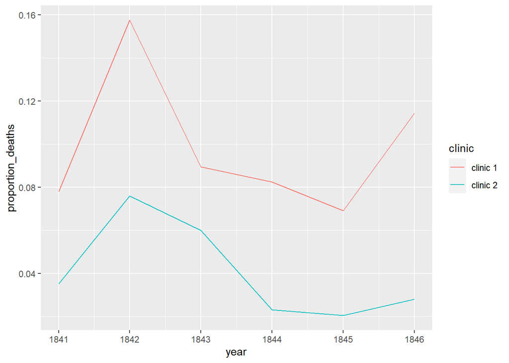

## Monthly Data

| date | births | deaths |
| --- | --- | --- |
| 1841-01-01 | 254 | 37 |
| 1841-02-01 | 239 | 18 |
| 1841-03-01 | 277 | 12 |
| 1841-04-01 | 255 | 4 |
| 1841-05-01 | 255 | 2 |
| 1841-06-01 | 200 | 10 |

| date | births | deaths | proportion_deaths |
| --- | --- | --- | --- |
| 1841-01-01 | 254 | 37 | 0.1456693 |
| 1841-02-01 | 239 | 18 | 0.0753138 |
| 1841-03-01 | 277 | 12 | 0.0433213 |
| 1841-04-01 | 255 | 4 | 0.0156863 |
| 1841-05-01 | 255 | 2 | 0.0078431 |
| 1841-06-01 | 200 | 10 | 0.0500000 |

## Plot monthly proportion of deaths

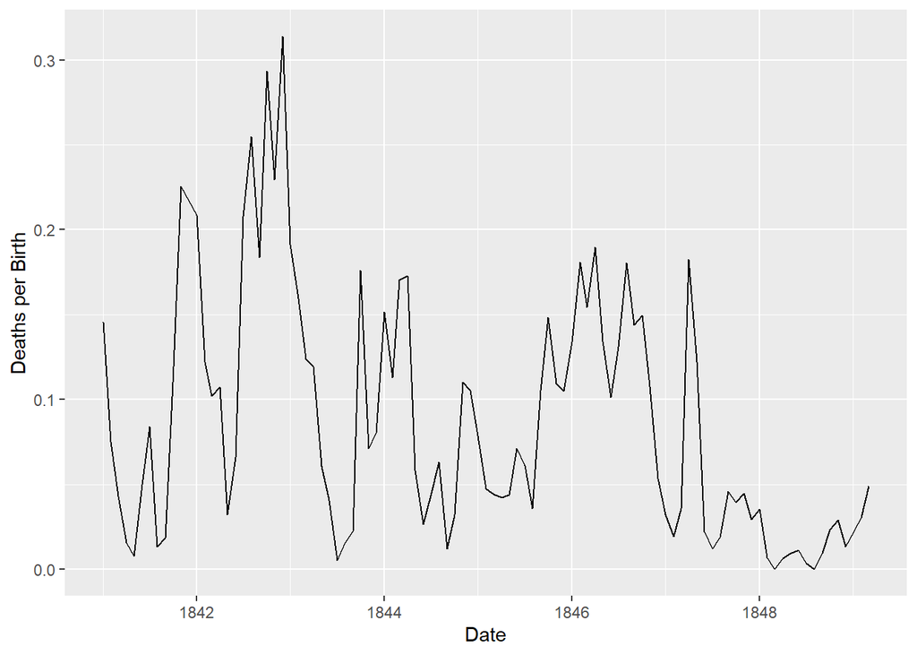

## Mandatory Handwashing

| date | births | deaths | proportion_deaths | handwashing_started |
| --- | --- | --- | --- | --- |
| 1841-01-01 | 254 | 37 | 0.1456693 | FALSE |
| 1841-02-01 | 239 | 18 | 0.0753138 | FALSE |
| 1841-03-01 | 277 | 12 | 0.0433213 | FALSE |
| 1841-04-01 | 255 | 4 | 0.0156863 | FALSE |
| 1841-05-01 | 255 | 2 | 0.0078431 | FALSE |
| 1841-06-01 | 200 | 10 | 0.0500000 | FALSE |

## Plot of when Handwashing Started

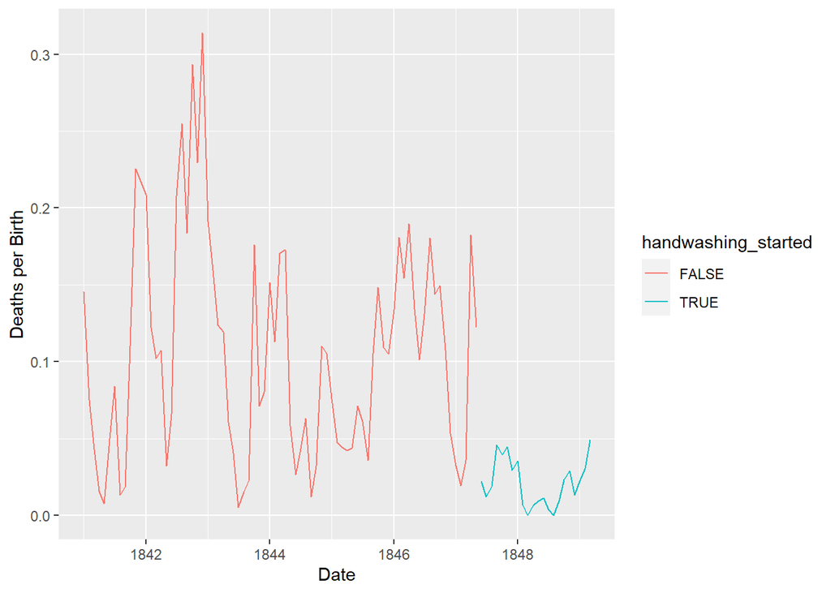

## Statistics

| handwashing_started | mean(proportion_deaths) |
| --- | --- |
| FALSE | 0.1050500 |
| TRUE | 0.0210934 |

```
##
##  Welch Two Sample t-test
##
## data:  proportion_deaths by handwashing_started
## t = 9.6101, df = 92.435, p-value = 1.445e-15
## alternative hypothesis: true difference in means is not equal to 0
## 95 percent confidence interval:
##  0.06660662 0.10130659
## sample estimates:
## mean in group FALSE  mean in group TRUE
##          0.10504998          0.02109338
```